# ETC3250/5250 Tutorial 11

#### 3. Music similarity

1. The `music` data was collected by extracting the first 40 seconds of each track from CDs using the music editing software Amadeus II, saved as a WAV file and analysed using the R package `tuneR`. Only a subset of the data is provided, with details:
- `title`: Title of the track
- `artist`: Abba, Beatles, Eels, Vivaldi, Mozart, Beethoven, Enya
- `type`: rock, classical, or new wave
- `lvar`, `lave`, `lmax`: average, variance, maximum of the frequencies of the left channel
- `lfener`: an indicator of the amplitude or loudness of the sound
- `lfreq`: median of the location of the 15 highest peak in the periodogram

You can read the data into R using:

```r
music <- read_csv("http://ggobi.org/book/data/music-sub.csv") |>
  rename(title = `...1`)
```

How many observations in the data? Explain how this should determine the maximum grid size for an SOM.

**Solution**

There are only 62 observations. If you use a 5x5 grid, this is less than 3 observations per cluster. You need to be careful about specifying a model with too many nodes for the number of observations. At the same time and SOM needs to have some flexibility to fit the data shape, and more nodes allows more flexibility.

2. Fit a SOM model to the data using a 4x4 grid, using a large `rlen` value. Be sure to standardise your data prior to fitting the model. Make a map of the results, and show the map in both 2D and 5D (using a tour).

**Solution**

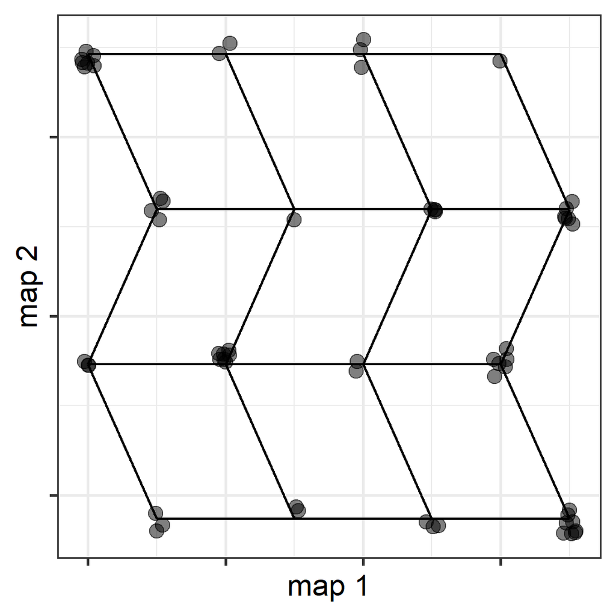

```r
set.seed(831)
music_std <- music |>
  mutate_if(is.numeric,
            function(x) (x-mean(x))/sd(x))
music_som1 <- som(as.matrix(music_std[,4:8]),
                 grid = somgrid(4, 4, "hexagonal"), rlen=2000)
music_som1_df_net <- som_model(music_som1)
music_som1_data <- music_som1_df_net$data |>
  mutate(cl = music_som1$unit.classif,
         title = music_std$title,
         artist = music_std$artist) |>
  select(id, title, artist, lvar:distance)

ggplot() +
  geom_segment(data=music_som1_df_net$edges_s,
               aes(x=x, xend=xend, y=y,
                   yend=yend)) +
  geom_point(data=music_som1_data,
             aes(x=map1, y=map2, label=paste(artist, title)),
             size=3, alpha=0.5) +
  xlab("map 1") + ylab("map 2") +
  theme(legend.position = "bottom",
        legend.title = element_blank(),
        axis.text = element_blank())
```

```r
# ggplotly()

# 5D
music_som1_map <- music_som1_df_net$net |>
  mutate(artist = "0",
         title = "0",
         type="net")
music_som1_data_tour <- music_som1_data |>
  select(lvar:lfreq, artist, title) |>
  mutate(type="data")
music_som1_map_data <- bind_rows(
  music_som1_map, music_som1_data_tour)
music_som1_map_data$type <- factor(music_som1_map_data$type,
  levels=c("net", "data"))
```

```r
#x11()
animate_xy(music_som1_map_data[,1:5],
           pch=music_som1_map_data$type,
           shapeset=c(46, 16),
           edges=as.matrix(music_som1_df_net$edges),
           edges.col = "black",
           axes="bottomleft")
```

3. Let’s take a look at how it has divided the data into clusters. Set up linked brushing between detourr and map view using the code below.

```r
music_som1_shared <- SharedData$new(music_som1_data)

music_detour <- detour(music_som1_shared, tour_aes(
  projection = lvar:lfreq)) |>
  tour_path(grand_tour(2),
            max_bases=50, fps = 60) |>
  show_scatter(alpha = 0.9, axes = FALSE,
               width = "100%", height = "450px")

music_map <- plot_ly(music_som1_shared,
     x = ~map1,
     y = ~map2,
     text = ~paste(title, artist),
     marker = list(color="black", size=8),
     height = 450) |>
  highlight(on = "plotly_selected",
            off = "plotly_doubleclick") |>
  add_trace(type = "scatter",
            mode = "markers")

bscols(
  music_detour, music_map,
  widths = c(5, 6)
)
```

Can you see a small cluster of Abba songs? Which two songs are outliers? Which Beethoven piece is most like a Beatles song?

## 👋 Finishing up

Make sure you say thanks and good-bye to your tutor. This is a time to also report what you enjoyed and what you found difficult.